# Visualization-Heart Diseases Part

Jingjing_Tang

12/9/2017

BST 260 Final Project Group: Chuying Ma, Jingjing Tang, Jie Yin, Xuewei Zhang

### Graph to show the spatial distribution

As for heart diseases, three related questions were asked: 1. Have you ever diagnosed with Heart Attack? 2. Have you ever diagnosed with Angina or Coronary Heart Disease? 3. Have you ever diagnosed with a Stroke? Since there are too many missing values in these three variables, only datasets from 2005 to 2010 are taken into account.

```r
library(maps)
library(ggplot2)
library(ggmap)
library(mapdata)
library(RColorBrewer)
data(county.fips)
head(county.fips)
```

```
##   fips        polyname
## 1 1001 alabama,autauga
## 2 1003 alabama,baldwin
## 3 1005 alabama,barbour
## 4 1007    alabama,bibb
## 5 1009  alabama,blount
## 6 1011 alabama,bullock
```

```r
cnty <- map_data("county")
stt <- map_data("state")

library(dplyr)
dat <- read.csv("data_3_expo.csv")
dat051<- read.csv("state_05.csv") %>% select(-full, -X)
dat061<- read.csv("state_06.csv") %>% select(-full, -X)
dat071<- read.csv("state_07.csv") %>% select(-full, -X)
dat081<- read.csv("2008_data_state.csv")
dat091<- read.csv("2009_data_state.csv")
dat101<- read.csv("2010_data_state.csv")
dat_state_05_10 <- rbind (dat051, dat061, dat071, dat081,dat091,dat101)

cnty2 <- cnty %>%
  mutate(polyname = paste(region,subregion,sep=",")) %>%
  left_join(county.fips, by="polyname")

cnty2.df1 <- inner_join(cnty2, dat, by=c("fips") )

state_code <- data.frame(state = c(1,2,4,5,6,8,9,10,11,12,13,15,16,17,18,19,20,21,22,23,24,25,26,27,28,29,30,31,32,33,34,35,36,37,38,39,40,41,42,44,45,46,47,48,49,50,51,53,54,55,56,66,72,78),
                         region = c("alabama", "alaska", "arizona", "arkansas", "california", "colorado", "connecticut", "delaware", "district of columbia", "florida", "georgia", "hawaii", "idaho", "illinois", "indiana", "iowa", "kansas", "kentucky", "louisiana", "maine", "maryland", "massachusetts", "michigan", "minnesota", "mississippi", "missouri", "montana", "nebraska", "nevada", "new hampshire", "new jersey", "new mexico", "new york", "north carolina", "north dakota", "ohio", "oklahoma", "oregon", "pennsylvania", "rhode island", "south carolina", "south dakota", "tennessee", "texas","utah", "vermont", "virginia", "washington", "west virginia", "wisconsin", "wyoming", "guam", "peurto rico", "virgin islands"))

stt2 <- stt %>%
  left_join(state_code, by="region")
stt2.df1 <- inner_join(stt2, dat_state_05_10, by=c("state") )
```

(currently don’t use it) #####county level p1 <- ggplot(cnty2.df1, aes(long, lat,group = group)) + geom_polygon(aes(fill = heartattack), colour = rgb(1,1,1,0.2)) + coord_quickmap()+ facet_wrap(~year)

p2 <- ggplot(cnty2.df1, aes(long, lat,group = group)) + geom_polygon(aes(fill = ACheartdis), colour = rgb(1,1,1,0.2)) + coord_quickmap()+ facet_wrap(~year)

p3 <- ggplot(cnty2.df1, aes(long, lat,group = group)) + geom_polygon(aes(fill = stroke), colour = rgb(1,1,1,0.2)) + coord_quickmap()+ facet_wrap(~year)

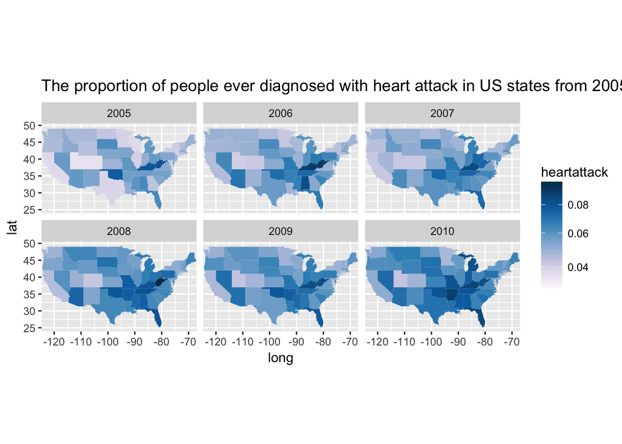

```r
#####state level
ggplot(stt2.df1, aes(long, lat,group = group)) +
  geom_polygon(aes(fill = heartattack))  + coord_quickmap() +
  scale_x_continuous(expand=c(0,0)) +
  scale_fill_gradientn(colors = brewer.pal(9, "PuBu"), trans = "sqrt") +
  facet_wrap(~year) +
  ggtitle("The proportion of people ever diagnosed with heart attack in US states from 2005 to 2010")
```

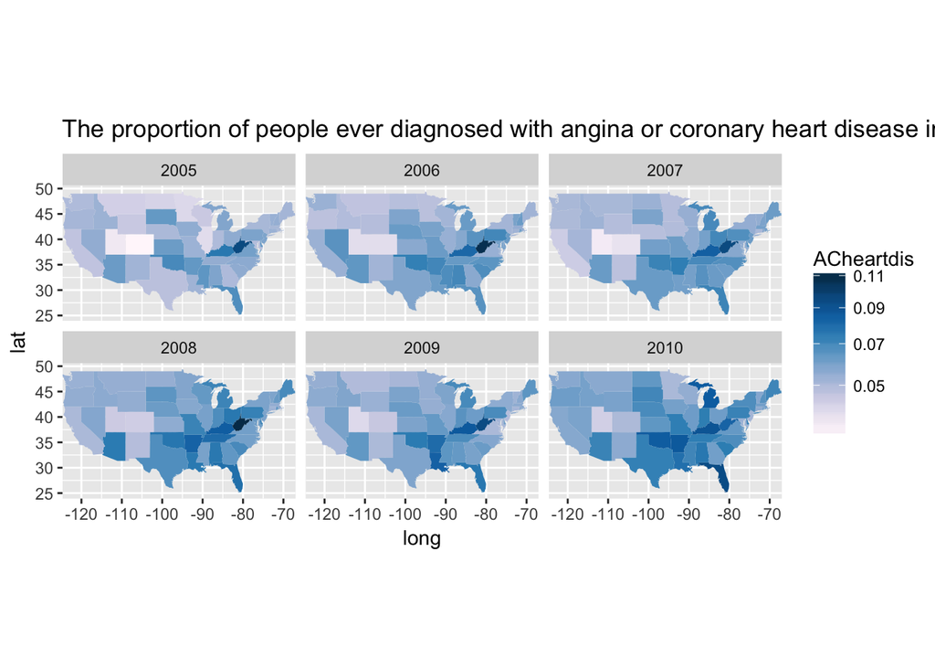

```r
ggplot(stt2.df1, aes(long, lat,group = group)) +
  geom_polygon(aes(fill = ACheartdis))  + coord_quickmap() +
  scale_x_continuous(expand=c(0,0)) +
  scale_fill_gradientn(colors = brewer.pal(9, "PuBu"), trans = "sqrt") +
  facet_wrap(~year) +
  ggtitle("The proportion of people ever diagnosed with angina or coronary heart disease in US states from 2005 to 2010")
```

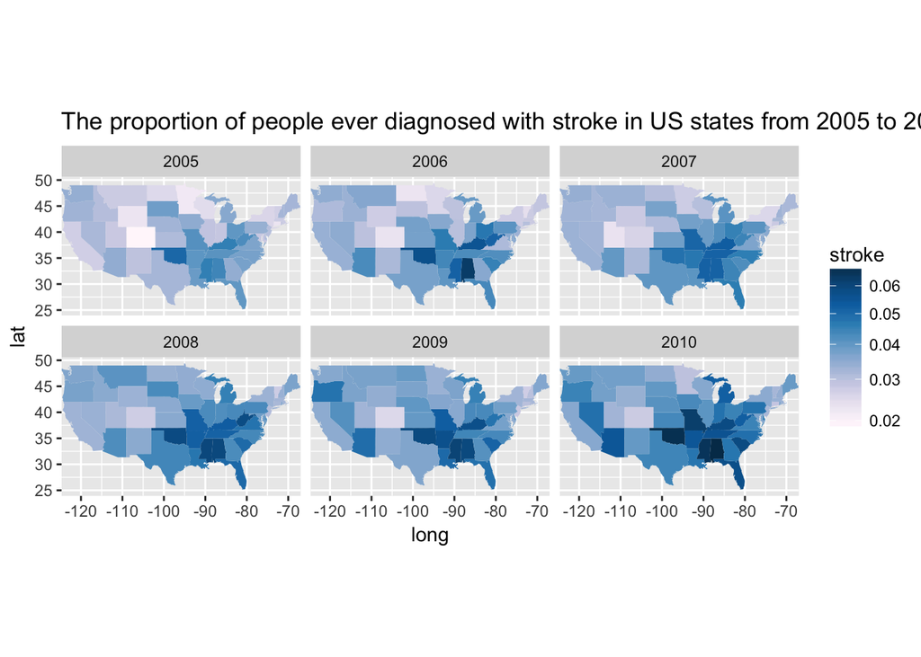

```r
ggplot(stt2.df1, aes(long, lat,group = group)) +
  geom_polygon(aes(fill = stroke))  + coord_quickmap() +
  scale_x_continuous(expand=c(0,0)) +
  scale_fill_gradientn(colors = brewer.pal(9, "PuBu"), trans = "sqrt") +
  facet_wrap(~year) +
  ggtitle("The proportion of people ever diagnosed with stroke in US states from 2005 to 2010")
```

## Paletts

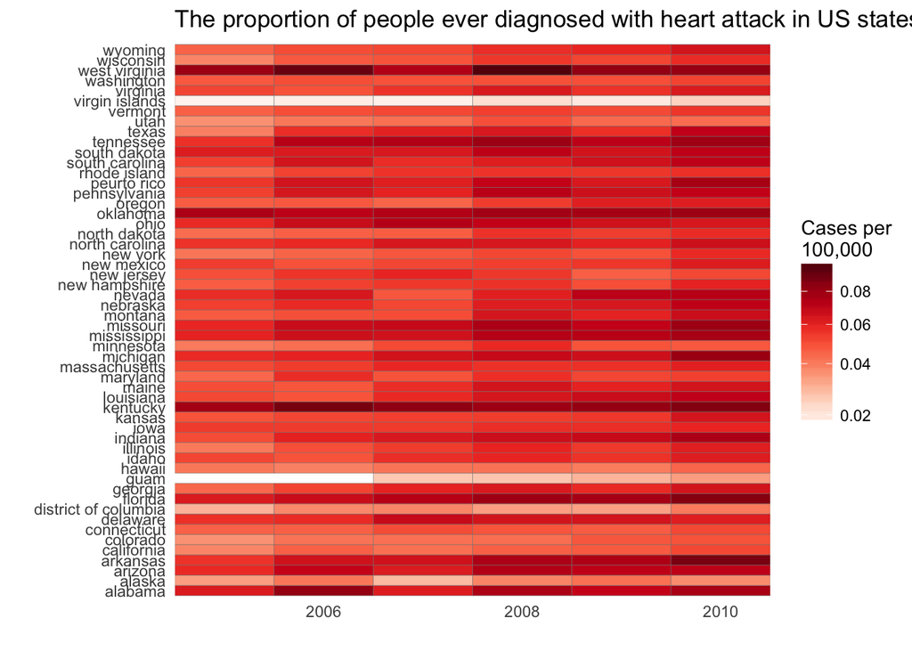

```r
library(RColorBrewer)
library(dplyr)
dat_state_05_10 %>%
  left_join(state_code, by="state") %>%
  group_by(year,region) %>%
  filter(!is.na(heartattack)) %>%
  summarize(heartattack = mean(heartattack)) %>%
    ggplot(aes(x = year, y = region,  fill = heartattack)) +
    geom_tile(color = "grey50") +
    scale_x_continuous(expand = c(0,0)) +
    scale_fill_gradientn("Cases per\n100,000",
                         colors = brewer.pal(9, "Reds"),
                         trans = "sqrt") +
    theme_minimal() +
    theme(panel.grid = element_blank()) +
    ggtitle("The proportion of people ever diagnosed with heart attack in US states from 2005 to 2010") +
    ylab("") + xlab("")
```

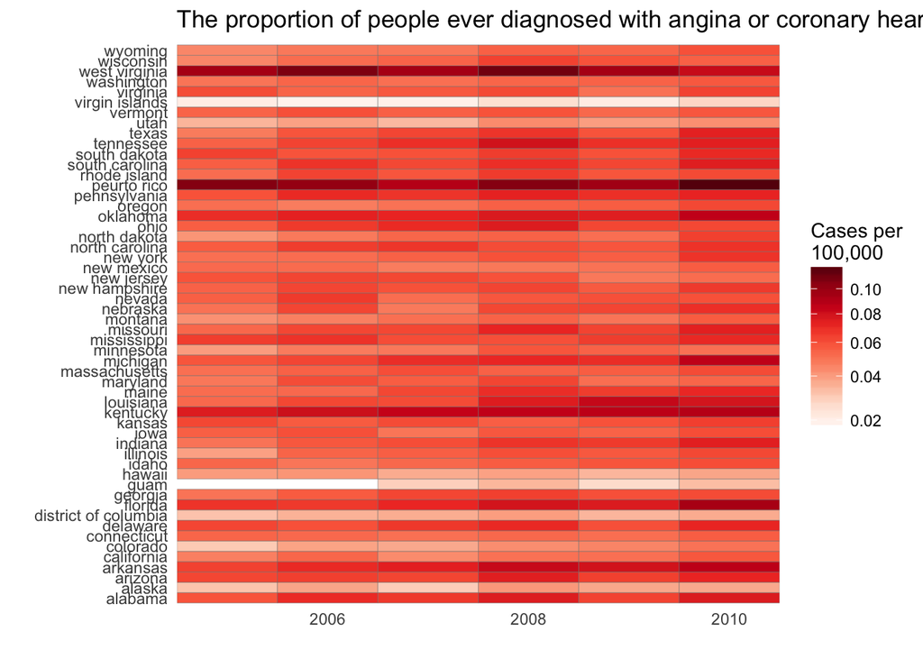

```r
dat_state_05_10 %>%
  left_join(state_code, by="state") %>%
  group_by(year,region) %>%
  filter(!is.na(ACheartdis)) %>%
  summarize(ACheartdis = mean(ACheartdis)) %>%
    ggplot(aes(x = year, y = region,  fill = ACheartdis)) +
    geom_tile(color = "grey50") +
    scale_x_continuous(expand = c(0,0)) +
    scale_fill_gradientn("Cases per\n100,000",
                         colors = brewer.pal(9, "Reds"),
                         trans = "sqrt") +
    theme_minimal() +
    theme(panel.grid = element_blank()) +
    ggtitle("The proportion of people ever diagnosed with angina or coronary heart disease in US states from 2005 to 2010") +
    ylab("") + xlab("")
```

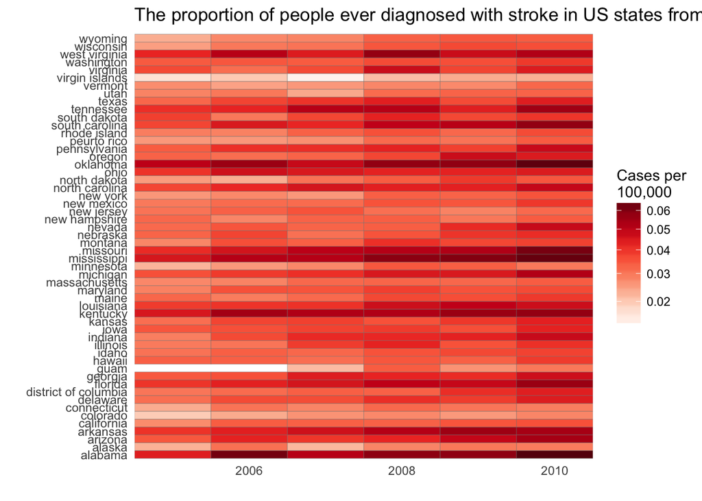

```r
dat_state_05_10 %>%
  left_join(state_code, by="state") %>%
  group_by(year,region) %>%
  filter(!is.na(stroke)) %>%
  summarize(stroke = mean(stroke)) %>%
    ggplot(aes(x = year, y = region,  fill = stroke)) +
    geom_tile(color = "grey50") +
    scale_x_continuous(expand = c(0,0)) +
    scale_fill_gradientn("Cases per\n100,000",
                         colors = brewer.pal(9, "Reds"),
                         trans = "sqrt") +
    theme_minimal() +
    theme(panel.grid = element_blank()) +
    ggtitle("The proportion of people ever diagnosed with stroke in US states from 2005 to 2010") +
    ylab("") + xlab("")
```

As expected, the distributions of heart attack rate, angina or coronary heart disease rate and stroke rate are very similar. It is apparent that rates of the three types of heart diseases in 2008-2010 is slightly higher than 2005-2007 especially in the South Eastern U.S. But does that mean you get a higher probability to develop a heart disease, if you live in the South Eastern US? Not exactly. Perhaps, this is just an interesting coincidence. What interests us is that the incidence of heart diseases in Kentucky, West Virginia or Puerto Rico is also very high, which lead to our thinking that there might be a link between heart diseases and mental health status.